# Cálculo I

Funciones

Elvis M. Sánchez Rogel

emsanchez@utmachala.edu.ec

Universidad Técnica de Machala

2026-05-31

# Preliniaminares

## ¿Qué es una función?

En este presentación, aprenderás

● La definición de una “función” en matemáticas (recordatorio: ¡nada que ver con una función de Python!).

● Terminología de funciones.

● Visualización de funciones.

● Funciones vs. salidas de funciones.

## ¿Qué es una función?

Función:

Una expresión o regla (o conjunto de expresiones) que asigna una variable (o conjunto de variables) a otra variable.

$${\color{goldenrod}y} = {\color{#c0392b}f}({\color{teal}x})$$

$${\color{#c0392b}f} : {\color{teal}x} \to {\color{goldenrod}y}$$

Función:

Una expresión o regla (o conjunto de expresiones) que asigna una variable (o conjunto de variables) a otra variable.

${\color{goldenrod}y} =$

${\color{#c0392b}f}({\color{teal}x})$

↓

Función

Función:

Una expresión o regla (o conjunto de expresiones) que asigna una variable (o conjunto de variables) a otra variable.

${\color{goldenrod}y} =$

${\color{#c0392b}f}$

↓

Función

$({\color{teal}x})$

↓

Entrada

(variable independiente)

Función:

Una expresión o regla (o conjunto de expresiones) que asigna una variable (o conjunto de variables) a otra variable.

${\color{goldenrod}y}$

↓

Salida

(variable dependiente)

$=$

${\color{#c0392b}f}$

↓

Función

$({\color{teal}x})$

↓

Entrada

(variable independiente)

Función:

Una expresión o regla (o conjunto de expresiones) que asigna una variable (o conjunto de variables) a otra variable.

${\color{#c0392b}f}({\color{teal}x})$

${\color{#c0392b}g}({\color{teal}x})$

${\color{#c0392b}h}({\color{teal}x})$

Función:

Una expresión o regla (o conjunto de expresiones) que asigna una variable (o conjunto de variables) a otra variable.

${\color{#c0392b}f}({\color{teal}x})$

${\color{#c0392b}g}({\color{teal}x})$

${\color{#c0392b}h}({\color{teal}x})$

${\color{#c0392b}exp}({\color{teal}x})$

${\color{#c0392b}ef}({\color{teal}x})$

${\color{#c0392b}erf}({\color{teal}x})$

Importante:

Cada valor de la entrada (x) produce a lo sumo un valor de la salida (y).

$${\color{goldenrod}y} = {\color{#c0392b}f}({\color{teal}x})$$

## Visualizando funciones

${\color{goldenrod}y} = {\color{#c0392b}f}({\color{teal}x}) = {\color{teal}x^2}$

${\color{goldenrod}y} = {\color{#c0392b}f}({\color{teal}x}) = {\color{teal}x^2}$

[figure not shown]

${\color{goldenrod}y} = {\color{#c0392b}f}({\color{teal}x}) = {\color{teal}x^2}$

${\color{goldenrod}y} = {\color{#c0392b}h}({\color{teal}x}) = {\color{goldenrod}\pi}$

[figure not shown]

Prueba de la línea vertical:

Si una línea vertical pasa por más de 1 punto, *no* es una función.

[figure not shown]

Prueba de la línea vertical:

Si una línea vertical pasa por más de 1 punto, *no* es una función.

[figure not shown]

${\color{#c0392b}f}({\color{teal}x}) = {\sqrt{\color{teal}{x}}}$

${\color{#c0392b}f}({\color{teal}x}) = {\sqrt{\color{teal}{x}}}$

[figure not shown]

${\color{#c0392b}f^+}({\color{teal}x}) = {\color{#c0392b}+\sqrt{x}}$

${\color{navy}f^-}({\color{teal}x}) = {\color{navy}-\sqrt{x}}$

[figure not shown]

## ¿Qué es una función?

${\color{goldenrod}y} = {\color{#c0392b}f}({\color{teal}x})$

Punto sutil:

$f$ es la(s) regla(s) que mapea variables independientes ($x$) hacia variables dependientes ($y$).

$y$ es un valor particular de la salida de una función para un valor particular de $x$.

## Tipos de funciones que encontrará

Polinómica  
Racional  
Algebraica  
Trigonométrica  
Compuesta  
Por tramos  
Continua

Lineal  
Potencia  
Exponencial  
Logarítmica  
Recíproca  
Trascendental  
Inversa

## Dominio y rango de una función

En esta presentación, aprenderás

● La definición de “dominio” y “rango” (pista: valores permisibles de las entradas/salidas de una función).

● Notaciones.

## Dominio y rango

Dominio:

Conjunto de todos los valores posibles de ${\color{teal}x}$ (entrada de la función).

Rango:

Conjunto de todos los valores posibles de ${\color{goldenrod}y}$ (salida de la función).

## Dominio y rango

**Dominio:** Todos los valores posibles de *x*.

**Rango:** Todos los valores de *y* mayores o iguales a 0 (no negativos).

[figure not shown]

## Dominio y rango en abstracto

[figure not shown]

## Definición de dominio

$${\color{#c0392b}y} = {\color{teal}x}^2$$

$${\color{teal}D} = [.5,\, 3.1]$$

$${\color{#c0392b}R} = [.25,\, 9.61]$$

[figure not shown]

## Notaciones para dominio y rango

Intervalo

$${\color{teal}D} = (-\infty,\,+\infty)$$

$${\color{#c0392b}R} = [0,\,\infty)$$

↙ Cota inclusiva

↘ Cota exclusiva

Desigualdad

$$-\infty < {\color{teal}x} < \infty$$

$${\color{#c0392b}y} \geq 0$$

Notación de conjuntos

$${\color{teal}D}:\{{\color{teal}x} \mid {\color{teal}x} \in \mathbb{R}\}$$

$${\color{#c0392b}R}:\{{\color{#c0392b}y} \mid {\color{#c0392b}y} \geq 0\}$$

$$(-\infty,\,0) \cup (0,\,2\pi]$$

## Funciones lineales vs no lineales

En esta presentación, aprenderás

● La intuición de funciones lineales vs. no lineales.

● Varias definiciones algebraicas de lineal vs. no lineal.

● ¡Un adelanto del objetivo del cálculo diferencial!

## Funciones lineales vs no lineales

Lineal

No lineal

## Intuición geométrica: Funciones lineales vs no lineales

[figure not shown]

## Definición algebraica #1: Lineal vs no lineal

**Lineal:** La función puede simplificarse a

$${\color{goldenrod}y} = {\color{goldenrod}m}{\color{teal}x} + {\color{goldenrod}b}$$

**No lineal:** La función **NO** puede simplificarse a

$${\color{#c0392b}y} = {\color{#c0392b}m}{\color{teal}x} + {\color{#c0392b}b}$$

$${\color{#c0392b}y} = 2{\color{teal}x} + 6$$

$${\color{#c0392b}y} = 2{\color{teal}x} + 6$$

$${\color{teal}x}{\color{#c0392b}y} = 3{\color{teal}x}^2 - 4{\color{teal}x}$$

$${\color{#c0392b}y} = 2\sqrt{\cos({\color{teal}x})} + 6$$

$${\color{#c0392b}y} = 3{\color{teal}x}^2 - 4$$

## Definición algebraica #1-a-: Lineal vs no lineal

Lineal:

La función puede simplificarse a

$${\color{goldenrod}y} = {\color{goldenrod}m}{\color{teal}x} + {\color{goldenrod}b}$$

No lineal:

La función **NO** puede simplificarse a

$${\color{#c0392b}y} = {\color{#c0392b}m}{\color{teal}x} + {\color{#c0392b}b}$$

$${\color{goldenrod}y} = 2{\color{teal}x} + 6$$

$${\color{goldenrod}y} = 2{\color{teal}x} + 6$$

$${\color{teal}x}{\color{goldenrod}y} = 3{\color{teal}x}^2 - 4{\color{teal}x}$$

$${\color{goldenrod}y} = 2\sqrt{\cos({\color{teal}x})} + 6$$

$${\color{goldenrod}y} = 3{\color{teal}x}^2 - 4$$

$${\color{goldenrod}y} = \sqrt{2}{\color{teal}x} + \cos(6)$$

## Definición algebraica #1-b-: Lineal vs no lineal

Lineal:

$$\frac{\Delta{\color{goldenrod}y}}{\Delta{\color{teal}x}} = {\color{navy}c}$$

No lineal:

$$\frac{\Delta{\color{goldenrod}y}}{\Delta{\color{teal}x}} \neq {\color{navy}c}$$

La razón del cambio en la salida respecto al cambio en la entrada es **constante**.

La relación entre la entrada y la salida de la función **cambia** dentro del dominio.

$${\color{goldenrod}y} = 2{\color{teal}x}$$

$${\color{goldenrod}y} = 2{\color{teal}x}$$

$${\color{goldenrod}y} = {\color{teal}x}^2$$

$${\color{goldenrod}y} = 2{\color{teal}x}$$

| ${\color{teal}x}$ | ${\color{goldenrod}y}$ | $\Delta y/\Delta x$ |
| --- | --- | --- |
| ${\color{teal}0}$ | ${\color{goldenrod}0}$ |  |
| ${\color{teal}2}$ | ${\color{goldenrod}4}$ | ${\color{goldenrod}4/2}$ |
| ${\color{teal}4}$ | ${\color{goldenrod}8}$ | ${\color{goldenrod}4/2}$ |
| ${\color{teal}6}$ | ${\color{goldenrod}12}$ | ${\color{goldenrod}4/2}$ |

$${\color{goldenrod}y} = {\color{teal}x}^2$$

$${\color{goldenrod}y} = 2{\color{teal}x}$$

| ${\color{teal}x}$ | ${\color{goldenrod}y}$ | $\Delta y/\Delta x$ |
| --- | --- | --- |
| ${\color{teal}0}$ | ${\color{goldenrod}0}$ |  |
| ${\color{teal}2}$ | ${\color{goldenrod}4}$ | ${\color{goldenrod}4/2}$ |
| ${\color{teal}4}$ | ${\color{goldenrod}8}$ | ${\color{goldenrod}4/2}$ |
| ${\color{teal}6}$ | ${\color{goldenrod}12}$ | ${\color{goldenrod}4/2}$ |

$${\color{goldenrod}y} = {\color{teal}x}^2$$

| ${\color{teal}x}$ | ${\color{goldenrod}y}$ | $\Delta y/\Delta x$ |
| --- | --- | --- |
| ${\color{teal}0}$ | ${\color{goldenrod}0}$ |  |
| ${\color{teal}2}$ | ${\color{goldenrod}4}$ | ${\color{goldenrod}4/2}$ |
| ${\color{teal}4}$ | ${\color{goldenrod}16}$ | ${\color{goldenrod}12/2}$ |
| ${\color{teal}6}$ | ${\color{goldenrod}36}$ | ${\color{goldenrod}20/2}$ |

La razón del cambio en la salida respecto al cambio en la entrada es **constante**.

La relación entre la entrada y la salida de la función **cambia** dentro del dominio.

## Funciones con subdominios lineales

[figure not shown]

## Funciones lineales vs afines

[figure not shown]

**En álgebra lineal:**

Lineal

Afín (no lineal)

## Funciones polinómicas

En esta sección, aprenderás

● Qué es una función polinómica.

● Aritmética con polinomios.

● La definición de una función racional.

● Por qué los polinomios son tan importantes en matemáticas.

## ¿Qué son los polinomios?

$${\color{#c0392b}y} = {\color{goldenrod}a_0} + {\color{goldenrod}a_1}{\color{teal}x} + {\color{goldenrod}a_2}{\color{teal}x}^2 + \ldots + {\color{goldenrod}a_n}{\color{teal}x}^n$$

**Coeficientes**

$${\color{#c0392b}y} = \boxed{{\color{goldenrod}a_0}} + \boxed{{\color{goldenrod}a_1}}{\color{teal}x} + \boxed{{\color{goldenrod}a_2}}{\color{teal}x}^2 + \ldots + \boxed{{\color{goldenrod}a_n}}{\color{teal}x}^n$$

$${\color{#c0392b}y} = {\color{goldenrod}a_0} + {\color{goldenrod}a_1}{\color{teal}x} + {\color{goldenrod}a_2}{\color{teal}x}^2 + \ldots + {\color{goldenrod}a_n}{\color{teal}x}^n$$

$$= {\color{goldenrod}a_0}{\color{teal}x}^0 + {\color{goldenrod}a_1}{\color{teal}x}^1 + {\color{goldenrod}a_2}{\color{teal}x}^2 + \ldots + {\color{goldenrod}a_n}{\color{teal}x}^n$$

$$= \sum_{i=0}^{n} {\color{goldenrod}a_i}{\color{teal}x}^i$$

$$f({\color{teal}x}) = {\color{goldenrod}3} - {\color{goldenrod}5}{\color{teal}x} + \frac{{\color{goldenrod}5}}{6}{\color{teal}x}^2 + {\color{goldenrod}12.4}{\color{teal}x}^3$$

$$g({\color{teal}x}) = {\color{goldenrod}2}{\color{teal}x} + {\color{teal}x}^3$$

## Visualización de polinomios

[figure not shown]

## Visualización de polinomios

[figure not shown]

## La intersección del polinomio

$$y = 2 + x + x^2 + x^3$$

[figure not shown]

$$y = \boxed{{\color{#c0392b}2}} + x + x^2 + x^3$$

[figure not shown]

## Suma de polinomios

$$\left({3-5\color{teal}x}+\frac{5}{6}{\color{teal}{x^2}}+{12.4\color{teal}{x^3}}\right) + \left({2\color{teal}{x}}+{\color{teal}{x^3}}\right) =$$

$$\left(3+\boxed{-5\color{teal}{x}}+\frac{5}{6}{\color{teal}{x^2}}+12.4{\color{teal}{x^3}}\right) + \left(\boxed{2{\color{teal}{x}}}+{\color{teal}x^3}\right) =$$

$$\left({3-5\color{teal}x}+\frac{5}{{6}}{\color{teal}x^2}+\boxed{{12.4\color{teal}{x^3}}}\right) + \left(2{\color{teal}x}+\boxed{{\color{teal}x^3}}\right) =$$

$$\left({3-5\color{teal}{x}}+\frac{5}{{6}}{\color{teal}x^2}+12.4{\color{teal}x^3}\right) + \left({2\color{teal}{x}}+{\color{teal}{x^3}}\right) =$$

## Ejemplo de multiplicación de polinomios

$$({\color{#c0392b}x^5} + 2{\color{#c0392b}x}{\color{blue}y} + {\color{blue}y^2})({\color{#c0392b}x} - 3{\color{#c0392b}x}{\color{blue}y})$$

$$({\color{#c0392b}x^5} + 2{\color{#c0392b}x}{\color{blue}y} + {\color{blue}y^2})({\color{#c0392b}x} - 3{\color{#c0392b}x}{\color{blue}y})$$

$${\color{#c0392b}x^6} - 3{\color{#c0392b}x^6}{\color{blue}y} + 2{\color{#c0392b}x^2}{\color{blue}y} - 6{\color{#c0392b}x^2}{\color{blue}y^2} + {\color{#c0392b}x}{\color{blue}y^2} - 3{\color{#c0392b}x}{\color{blue}y^3}$$

$$(\boxed{{\color{#c0392b}x^5}} + 2{\color{#c0392b}x}{\color{blue}y} + {\color{blue}y^2})(\boxed{{\color{#c0392b}x}} - 3{\color{#c0392b}x}{\color{blue}y})$$

$${\color{#c0392b}x^6} - 3{\color{#c0392b}x^6}{\color{blue}y} + 2{\color{#c0392b}x^2}{\color{blue}y} - 6{\color{#c0392b}x^2}{\color{blue}y^2} + {\color{#c0392b}x}{\color{blue}y^2} - 3{\color{#c0392b}x}{\color{blue}y^3}$$

$$(\boxed{{\color{#c0392b}x^5}} + 2{\color{#c0392b}x}{\color{blue}y} + {\color{blue}y^2})({\color{#c0392b}x} + \boxed{-3{\color{#c0392b}x}{\color{blue}y}})$$

$${\color{#c0392b}x^6} - 3{\color{#c0392b}x^6}{\color{blue}y} + 2{\color{#c0392b}x^2}{\color{blue}y} - 6{\color{#c0392b}x^2}{\color{blue}y^2} + {\color{#c0392b}x}{\color{blue}y^2} - 3{\color{#c0392b}x}{\color{blue}y^3}$$

## Funciones racionales

$r(x) = \frac{{\color{teal}P}(x)}{{\color{goldenrod}Q}(x)}$

$r({\color{teal}x}) = \frac{P({\color{teal}x})}{Q({\color{teal}x})} = \frac{\displaystyle\sum_{i=0}^{n} {\color{orange}a_i}{\color{teal}x}^i}{\displaystyle\sum_{i=0}^{k} {\color{orange}b_i}{\color{teal}x}^i}$

## Polinomios en la naturaleza

- En todos los cursos de cálculo…
- Filtrado de series de tiempo
- Interpolación
- Velocidad de computación
- Optimizaciones
- Gráficos de computadora (videojuegos)
- Economía

## Trascendental y las matemáticas

${\cos(x),\sin(x)}$

${\log(x),\exp(x)}$

## Funciones logarítmicas y exponenciales

**En esta sección aprenderás:**

●

Qué es la función exponencial natural y de dónde proviene.

●

Las características de las funciones exponenciales y logarítmicas.

●

Un repaso de logaritmos.

## Exponencial natural

${\color{teal}e^x} = {\color{goldenrod}exp(x)}$

[figure not shown]

Siempre positiva

[figure not shown]

Siempre positiva

Tiende a 0 cuando x → -∞

[figure not shown]

Siempre positiva

Tiende a 0 cuando x → -∞

Tiende a +∞ cuando x → +∞

[figure not shown]

## ¿De dónde viene $e$?

${\color{goldenrod}e} = \displaystyle{{\color{navy}\lim}_{{\color{navy}n\to\infty}}\left(1+\frac{1}{{\color{navy}n}}\right)^{{\color{navy}n}}}$

[figure not shown]

## El número $e$ en la naturaleza

[figure not shown]

## Banco 3

[figure not shown]

## ¿Cuál banco es mejor?

[figure not shown]

## Banco 12

[figure not shown]

## En general: Banco $n$

[figure not shown]

## $n$ bancos

[figure not shown]

## Convergencia a $e$

[figure not shown]

## El banco al final del universo

[figure not shown]

## Logaritmo natural y $e$

Indefinida para $x \leq 0$

Tiende a $-\infty$ cuando $x \to 0$

Tiende a $+\infty$ cuando $x \to \infty$

La tasa de crecimiento disminuye

[figure not shown]

## Logaritmo natural y $e$ — inversas

[figure not shown]

${\color{#c0392b}ln}({\color{goldenrod}e}^x) = {\color{blue}x}$

$D(x \in \mathbb{R}),\; R(y \in \mathbb{R})$

${\color{goldenrod}e}^{{\color{#c0392b}ln}(x)} = {\color{blue}x}$

$D(x > 0),\; R(y > 0)$

## Logaritmos

$${\color{teal}x} = {\color{#c0392b}b}^{{\color{goldenrod}y}}$$

$${\color{goldenrod}y} = {\color{goldenrod}log}_{{\color{#c0392b}b}}({\color{teal}x})$$

$${\color{#c0392b}b} > 0$$

[figure not shown]

## Funciones trigonométricas

En esta sesión, aprenderás

- Las principales funciones trigonométricas y cómo se definen.
- Cómo determinar valores de $\sin$ y $\cos$ visualmente.
- La identidad trigonométrica más importante (?).

## Definición de funciones trigonométricas

[figure not shown]

## Animación de $\sin$ y $\cos$

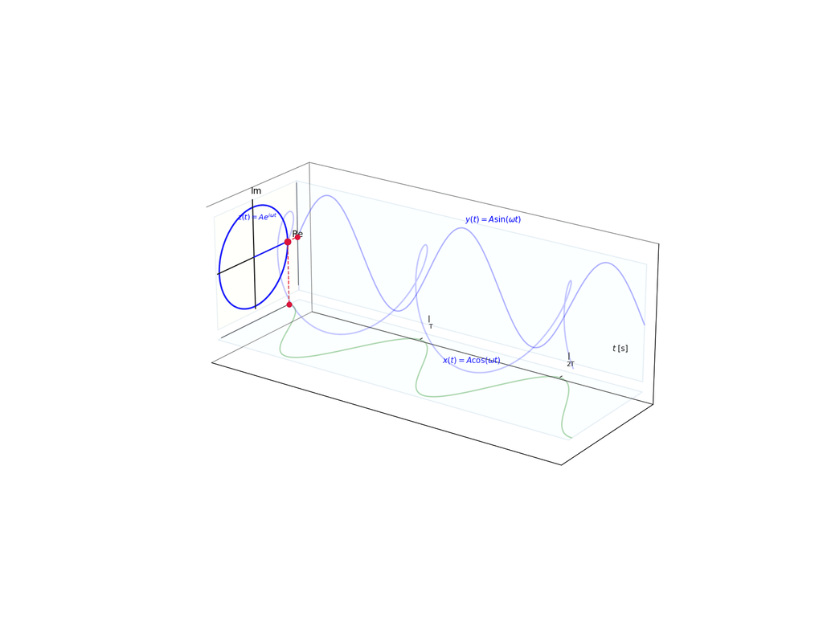

script

## Trigonometría

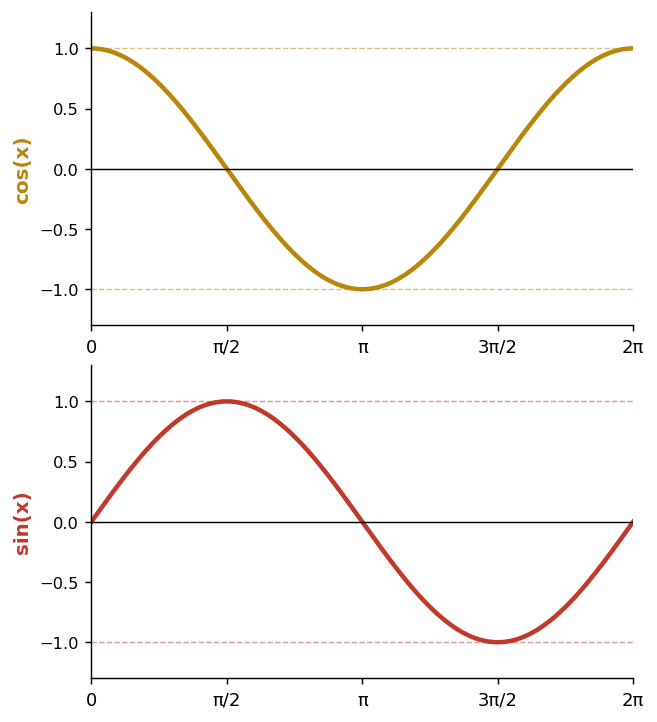

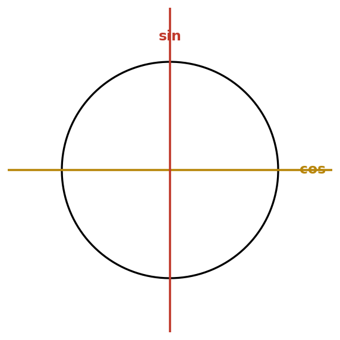

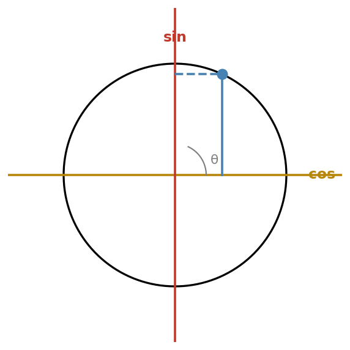

## Función tangente

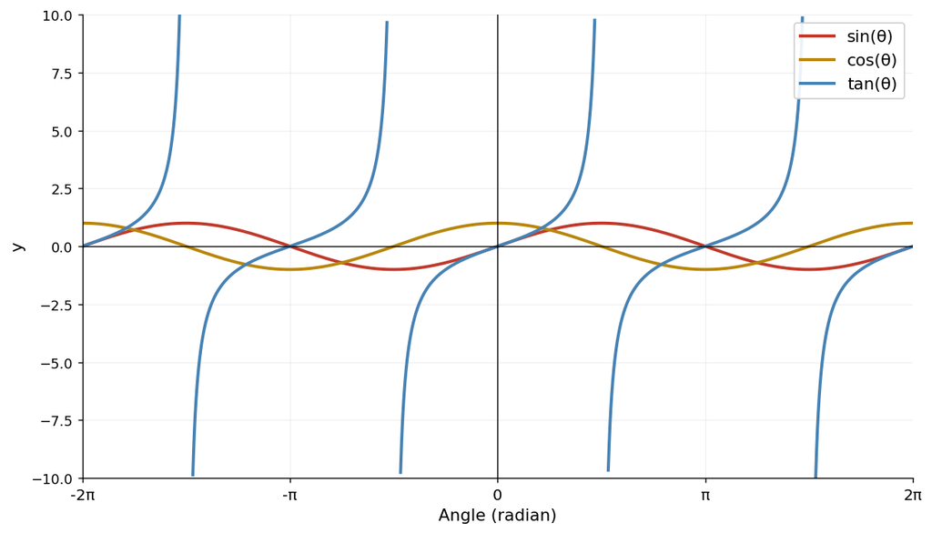

## Identidad trigonométrica

$$\cos(2\theta) = \cos^2(\theta) - \sin^2(\theta)$$

$$\cos^2(\theta) + \sin^2(\theta) = 1$$

$$\cos^2(\theta) + \sin^2(\theta) = 1$$

[figure not shown]

$$\cos^2(\theta) + \sin^2(\theta) = 1$$

[figure not shown]

$$\to {\color{steelblue}h} = \sqrt{(x_1 - x_2)^2 + (y_1 - y_2)^2}$$

$$\cos^2(\theta) + \sin^2(\theta) = 1$$

[figure not shown]

$${\color{goldenrod}\cos^2}(\theta) + {\color{#c0392b}\sin^2}(\theta) = 1$$

$${\color{goldenrod}\cos^2}(\theta) + {\color{#c0392b}\sin^2}(\theta) = 1$$

$$\left(\frac{{\color{goldenrod}a}}{h}\right)^2 + \left(\frac{{\color{#c0392b}o}}{h}\right)^2 = 1$$

$${\color{goldenrod}\cos^2}(\theta) + {\color{#c0392b}\sin^2}(\theta) = 1$$

$$\left(\frac{{\color{goldenrod}a}}{h}\right)^2 + \left(\frac{{\color{#c0392b}o}}{h}\right)^2 = 1$$

$$\sqrt{\left(\frac{{\color{goldenrod}a}}{h}\right)^2 + \left(\frac{{\color{#c0392b}o}}{h}\right)^2} = 1$$

$${\color{goldenrod}\cos^2}(\theta) + {\color{#c0392b}\sin^2}(\theta) = 1$$

$$\left(\frac{{\color{goldenrod}a}}{h}\right)^2 + \left(\frac{{\color{#c0392b}o}}{h}\right)^2 = 1$$

$$\frac{{\color{goldenrod}a}^2}{h^2} + \frac{{\color{#c0392b}o}^2}{h^2} = 1$$

$${\color{goldenrod}\cos^2}(\theta) + {\color{#c0392b}\sin^2}(\theta) = 1$$

$$\left(\frac{{\color{goldenrod}a}}{h}\right)^2 + \left(\frac{{\color{#c0392b}o}}{h}\right)^2 = 1$$

$$\frac{{\color{goldenrod}a}^2}{h^2} + \frac{{\color{#c0392b}o}^2}{h^2} = 1$$

$$\frac{{\color{goldenrod}a}^2 + {\color{#c0392b}o}^2}{h^2} = 1$$

$${\color{goldenrod}\cos^2}(\theta) + {\color{#c0392b}\sin^2}(\theta) = 1$$

$$\left(\frac{{\color{goldenrod}a}}{h}\right)^2 + \left(\frac{{\color{#c0392b}o}}{h}\right)^2 = 1$$

$$\frac{{\color{goldenrod}a}^2}{h^2} + \frac{{\color{#c0392b}o}^2}{h^2} = 1$$

$$\frac{{\color{goldenrod}a}^2 + {\color{#c0392b}o}^2}{h^2} = 1$$

$${\color{goldenrod}a}^2 + {\color{#c0392b}o}^2 = h^2$$

## Identidad trigonométrica

**Angle sum and difference identities**

*See also:* Proofs of trigonometric identities § Angle sum identities, and Small-angle difference

These are also known as the *angle addition and subtraction theorems* (or *formulae*).

$$\begin{align}
\sin(\alpha + \beta) &= \sin\alpha\cos\beta + \cos\alpha\sin\beta \\[0.15em]
\sin(\alpha - \beta) &= \sin\alpha\cos\beta - \cos\alpha\sin\beta \\[0.15em]
\cos(\alpha + \beta) &= \cos\alpha\cos\beta - \sin\alpha\sin\beta \\[0.15em]
\cos(\alpha - \beta) &= \cos\alpha\cos\beta + \sin\alpha\sin\beta
\end{align}$$

https://en.wikipedia.org/wiki/List_of_trigonometric_identities

## Otras funciones trigonométricas

sin

cos

tan

csc

sec

cot

asin

acos

atan

acsc

asec

acot

## Funciones por partes

En esta sesión, aprenderás

- Qué es una «función por partes».
- La notación para funciones por partes.
- La función por partes simple que hace al aprendizaje profundo tan poderoso!

## ¿Qué es una función por partes?

Una función por partes es una función especificada en diferentes partes.

Cada parte es una función con su propio subdominio.

$$f(x) = \begin{cases} x/2 & \text{si }\ {\color{teal}x < 0} \\[0.4em] x^2 + 1 & \text{si }\ {\color{teal}0 \leq x < 3} \\[0.4em] -\ln(x) & \text{de lo contrario} \end{cases}$$

## Ejemplo de función por partes

[figure not shown]

$$f(x) = \begin{cases} x/2 & \text{si }\ {\color{teal}x < 0} \\[0.3em] x^2+1 & \text{si }\ {\color{teal}0 \leq x < 3} \\[0.3em] -\ln(x) & \text{en otro caso} \end{cases}$$

[figure not shown]

$f(x) =$

$x/2$ si ${\color{teal} x < 0}$

$x^2+1$ si ${\color{teal} 0 \leq x < 3}$

$-\ln(x)$ en otro caso

$$f(x) = \begin{cases} x & \text{cuando }\ {\color{teal}x \geq 0} \\[0.6em] -x & \text{cuando }\ {\color{teal}x < 0} \end{cases}$$

[figure not shown]

$$f(x) = \begin{cases} x & \text{cuando }\ {\color{teal}x \geq 0} \\[0.6em] -x & \text{cuando }\ {\color{teal}x < 0} \end{cases}$$

[figure not shown]

$f(x) =$

$x$ cuando ${\color{teal} x \geq 0}$

$-x$ cuando ${\color{teal} x < 0}$

[figure not shown]

«ReLU»  
(unidad lineal rectificada)

$$f(x) = \begin{cases} 0 & {\color{teal} ,\quad x < 0} \\[0.5em] x & {\color{teal} ,\quad x \geq 0} \end{cases}$$

## Funciones continuas y discontinuas

En esta sesión, aprenderás

- La diferencia entre funciones continuas y discontinuas.
- La definición formal y la prueba de continuidad.
- Los tres tipos de discontinuidades.

## Funciones y sus discontinuidades

[figure not shown]

Continua

[figure not shown]

Discontinuidad de salto

Continua

[figure not shown]

Discontinuidad de salto

Continua

Discontinuidad infinita

[figure not shown]

Discontinuidad de salto

Continua

Discontinuidad infinita

Discontinuidad removible

## Ejemplos de discontinuidades

[figure not shown]

**Discontinuidad de salto**

**Discontinuidad infinita**

**Discontinuidad removible**

$$f(x) = \begin{cases}
\dfrac{x}{2} & \text{si } x < 0 \\[0.6em]
x^{2} + 1 & \text{si } 0 \leq x < 1
\end{cases}$$

$$f(\theta) = \tan(\theta) = \frac{\sin(\theta)}{\cos(\theta)}$$

$$f(x) = \frac{x^{2} - 2x}{x^{2} - 4}$$

## Definición de continuidad

Una función $f({\color{teal}x})$ es continua en ${\color{teal}x}={\color{#c0392b}a}$ si se cumplen las siguientes tres condiciones; de lo contrario, la función es discontinua en el punto ${\color{#c0392b}a}$.

**1.** $\;f(\color{maroon}{a})$ está definida.

**2.** $\;\displaystyle\lim_{\color{teal}{x} \to \color{maroon}{a}} f(\color{teal}{x})$ existe.

**3.** $\;\displaystyle\lim_{\color{teal}{x} \to \color{maroon}{a}} f(\color{teal}{x}) = f(\color{maroon}{a})$.

[figure not shown]

## Teorema del valor intermedio

En esta presentación, aprenderás

- La intuición del teorema del valor intermedio.
- La condición y la definición formal del teorema del valor intermedio.
- Una aplicación del teorema del valor intermedio para resolver ecuaciones.

## Teorema del valor intermedio: intuición

[figure not shown]

## Teorema del valor intermedio: casos de falla

[figure not shown]

## Teorema del valor intermedio: definición

Teorema del valor intermedio

Una función que es continua en $[{\color{maroon}a},\, {\color{maroon}b}]$ tiene todos los valores entre $f({\color{maroon}a})$ y $f({\color{maroon}b})$.

## Ejemplo de aplicación: raíces de polinomios

[figure not shown]

Tiene raíces reales

[figure not shown]

No tiene raíces reales

## Funciones compuestas

[figure not shown]

## Ejemplos de funciones compuestas

${\color{goldenrod}f}(x) = 2x^2 - 4$

${\color{teal}g}(x) = 7x + 3$

${\color{goldenrod}f}({\color{teal}g}(x)) =$

${\color{teal}g}({\color{goldenrod}f}(x)) =$

$$\begin{aligned} {\color{goldenrod}f}({\color{teal}g}(x)) &= 2(7x+3)^2 - 4 \\ &= 2(7x+3)(7x+3) - 4 \\ &= 2\left(49x^2 + 21x + 21x + 9\right) - 4 \\ &= 98x^2 + 84x + 14 \end{aligned}$$

$$\begin{aligned} {\color{teal}g}({\color{goldenrod}f}(x)) &= 7(2x^2 - 4) + 3 \\ &= 14x^2 - 28 + 3 \\ &= 14x^2 - 25 \end{aligned}$$

## Propiedad conmutativa

${\color{goldenrod}3} \times {\color{maroon}4} = {\color{maroon}4} \times {\color{goldenrod}3}$

${\color{goldenrod}3} + {\color{maroon}4} = {\color{maroon}4} + {\color{goldenrod}3}$

${\color{goldenrod}3} - {\color{maroon}4} \neq {\color{maroon}4} - {\color{goldenrod}3}$

## Conmutatividad bajo la composición

En general:

${\color{goldenrod}f}({\color{teal}g}({\color{teal}x})) \neq {\color{teal}g}({\color{goldenrod}f}({\color{teal}x}))$

${\color{goldenrod}f}({\color{teal}g}({\color{teal}x})) \neq {\color{teal}g}({\color{goldenrod}f}({\color{teal}x}))$

${\color{goldenrod}f}({\color{teal}g}({\color{teal}x})) \neq {\color{teal}g}({\color{goldenrod}f}({\color{teal}x}))$

$\quad {\color{goldenrod}f}(x) = 2x^2 - 4$

$\quad {\color{teal}g}(x) = 7x + 3$

${\color{goldenrod}f}({\color{teal}g}({\color{teal}x})) \neq {\color{teal}g}({\color{goldenrod}f}({\color{teal}x}))$

$\quad {\color{goldenrod}f}(x) = 2x^2 - 4$

$\quad {\color{teal}g}(x) = 7x + 3$

$\quad {\color{goldenrod}f}(x) = 2x + 3$

$\quad {\color{teal}g}(x) = \dfrac{x-3}{2}$

${\color{goldenrod}f}({\color{teal}g}(x)) =$

${\color{teal}g}({\color{goldenrod}f}(x)) =$

## Notación de función compuesta

${\color{teal}g}({\color{goldenrod}f}({\color{teal}x})) \longleftrightarrow ({\color{teal}g} \circ {\color{goldenrod}f})(x)$

## Una mirada a la función compuesta

${\color{goldenrod}f}(x) = \sin(x)$

${\color{#c0392b}g}(x) = \sqrt{x}$

${\color{#1a5276}h}(x) = 2x^2 + 5$

${\color{goldenrod}f}({\color{#c0392b}g}({\color{#1a5276}h}(x))) = \sin\!\left(\sqrt{2x^2+5}\right)$

## Inversa como composición inversa

Conmutatividad bajo la composición

${\color{goldenrod}f}({\color{teal}g}({\color{teal}x})) \neq {\color{teal}g}({\color{goldenrod}f}({\color{teal}x}))$

$\quad {\color{goldenrod}f}(x) = 2x^2 - 4$

$\quad {\color{teal}g}(x) = 7x + 3$

$\quad {\color{goldenrod}f}(x) = 2x + 3$

$\quad {\color{teal}g}(x) = \dfrac{x-3}{2}$

${\color{goldenrod}f}({\color{teal}g}(x)) = x$

${\color{teal}g}({\color{goldenrod}f}(x)) = x$

## Función inversa

${\color{teal}g}(x)$ es la inversa de ${\color{goldenrod}f}(x)$ si

${\color{teal}g}({\color{goldenrod}f}(x)) = x$

## Notación de la inversa

${\color{#c0392b}f}^{-1}({\color{goldenrod}f}({\color{teal}x})) = {\color{teal}x}$

${\color{#c0392b}f}^{-1}({\color{goldenrod}f}({\color{teal}x})) = {\color{teal}x}$

${\color{goldenrod}f}({\color{teal}x})^{-1} = \dfrac{1}{{\color{goldenrod}f}({\color{teal}x})}$

${\color{#c0392b}f}^{-1}({\color{goldenrod}f}({\color{teal}x})) = {\color{teal}x}$

${\color{goldenrod}f}({\color{teal}x})^{-1} = \dfrac{1}{{\color{goldenrod}f}({\color{teal}x})}$

$3^{-1} \times 3 = \dfrac{1}{3} \times 3 = 1$

${\color{#c0392b}f}^{-1}({\color{goldenrod}f}({\color{teal}x})) = {\color{teal}x}$

${\color{goldenrod}f}({\color{teal}x})^{-1} = \dfrac{1}{{\color{goldenrod}f}({\color{teal}x})}$

${\color{goldenrod}f}^2({\color{teal}x}) = {\color{goldenrod}f}({\color{teal}x})\,{\color{goldenrod}f}({\color{teal}x})$

${\color{#c0392b}f}^{-1}({\color{goldenrod}f}({\color{teal}x})) = {\color{teal}x}$

${\color{goldenrod}f}({\color{teal}x})^{-1} = \dfrac{1}{{\color{goldenrod}f}({\color{teal}x})}$

${\color{goldenrod}f}^2({\color{teal}x}) = {\color{goldenrod}f}({\color{teal}x})\,{\color{goldenrod}f}({\color{teal}x})$

${\color{#c0392b}f}^{-1}({\color{teal}x})\,{\color{goldenrod}f}^2({\color{teal}x}) = {\color{goldenrod}f}({\color{teal}x})$

${\color{#c0392b}f}^{-1}({\color{goldenrod}f}({\color{teal}x})) = {\color{teal}x}$

${\color{goldenrod}f}({\color{teal}x})^{-1} = \dfrac{1}{{\color{goldenrod}f}({\color{teal}x})}$

${\color{goldenrod}f}^2({\color{teal}x}) = {\color{goldenrod}f}({\color{teal}x})\,{\color{goldenrod}f}({\color{teal}x})$

${\color{#c0392b}f}^{-1}({\color{teal}x})\,{\color{goldenrod}f}^2({\color{teal}x}) = {\color{goldenrod}f}({\color{teal}x})$

${\color{#c0392b}f}^{-1}({\color{teal}x})\,{\color{goldenrod}f}({\color{teal}x}) = {\color{goldenrod}f}^0({\color{teal}x})$

## La idea de la función inversa

[figure not shown]

## Notando la inversa

${\color{#c0392b}f}^{-1}({\color{goldenrod}f}({\color{teal}x})) = {\color{teal}x}$

${\color{goldenrod}f}({\color{teal}x})^{-1} = \dfrac{1}{{\color{goldenrod}f}({\color{teal}x})}$

${\color{goldenrod}f}^2({\color{teal}x}) = {\color{goldenrod}f}({\color{teal}x})\,{\color{goldenrod}f}({\color{teal}x})$

${\color{#c0392b}f}^{-1}({\color{teal}x})\,{\color{goldenrod}f}^2({\color{teal}x}) = {\color{goldenrod}f}({\color{teal}x})$

${\color{#c0392b}f}^{-1}({\color{teal}x})\,{\color{goldenrod}f}({\color{teal}x}) = {\color{goldenrod}f}^0({\color{teal}x})$

## Cálculo de la función inversa

Para calcular la inversa a mano (¡o con sympy!):

1. Expresa la función como ${\color{goldenrod}y} = \ldots$
2. Despeja ${\color{teal}x}$
3. Intercambia ${\color{teal}x}$ e ${\color{goldenrod}y}$

## Cálculo de la inversa: ejemplo

${\color{goldenrod}f}({\color{teal}x}) = 2{\color{teal}x} + 3$

Paso 1

{

${\color{maroon}y} = 2{\color{teal}x} + 3$

Paso 2

{

${\color{maroon}y} - 3 = 2{\color{teal}x}$

$({\color{maroon}y} - 3)/2 = {\color{teal}x}$

Paso 3

{

$({\color{teal}x} - 3)/2 = {\color{maroon}y} = {\color{maroon}f}^{-1}({\color{teal}x})$

## Cálculo de la inversa mediante álgebra

${\color{goldenrod}f}({\color{teal}\theta}) = \sin(2\pi{\color{teal}\theta})$

${\color{goldenrod}f}({\color{teal}\theta}) = \sin(2\pi{\color{teal}\theta})$

$\arcsin({\color{maroon}y}) = 2\pi{\color{teal}\theta}$

$\dfrac{\arcsin({\color{maroon}y})}{2\pi} = {\color{teal}\theta}$

$\dfrac{\arcsin({\color{teal}\theta})}{2\pi} = {\color{maroon}f}^{-1}({\color{teal}\theta})$

${\color{goldenrod}f}({\color{teal}\theta}) = \sin(2\pi{\color{teal}\theta})$

$\arcsin({\color{maroon}y}) = 2\pi{\color{teal}\theta}$

$\dfrac{\arcsin({\color{maroon}y})}{2\pi} = {\color{teal}\theta}$

$\dfrac{\arcsin({\color{teal}\theta})}{2\pi} = {\color{maroon}f}^{-1}({\color{teal}\theta})$

[figure not shown]

${\color{goldenrod}f}({\color{teal}\theta}) = 2{\color{teal}\theta}\sin(2\pi{\color{teal}\theta})$

${\color{goldenrod}f}({\color{teal}\theta}) = 2{\color{teal}\theta}\sin(2\pi{\color{teal}\theta})$

$\arcsin\!\left(\dfrac{{\color{maroon}y}}{2{\color{teal}\theta}}\right) = 2\pi{\color{teal}\theta}$

$\dfrac{\arcsin\!\left(\frac{{\color{maroon}y}}{2{\color{teal}\theta}}\right)}{2\pi} = {\color{teal}\theta}$

${\color{goldenrod}f}({\color{teal}x}) = 3{\color{teal}x}^2 + 4$

${\color{goldenrod}f}({\color{teal}x}) = 3{\color{teal}x}^2 + 4$

${\color{maroon}y} - 4 = 3{\color{teal}x}^2$

$\dfrac{{\color{maroon}y} - 4}{3} = {\color{teal}x}^2$

$\sqrt{\dfrac{{\color{maroon}y} - 4}{3}} = {\color{teal}x}$

$\sqrt{\dfrac{{\color{teal}x} - 4}{3}} = {\color{maroon}f}^{-1}({\color{teal}x})$

${\color{goldenrod}f}({\color{teal}x}) = 3{\color{teal}x}^2 + 4$

${\color{maroon}y} - 4 = 3{\color{teal}x}^2$

$\dfrac{{\color{maroon}y} - 4}{3} = {\color{teal}x}^2$

$\sqrt{\dfrac{{\color{maroon}y} - 4}{3}} = {\color{teal}x}$

$\sqrt{\dfrac{{\color{teal}x} - 4}{3}} = {\color{maroon}f}^{-1}({\color{teal}x})$

[figure not shown]

## Dominios y rangos de funciones inversas

$f(x)$

$f^{-1}(x)$

Dominio

$\longrightarrow$

Rango

Rango

$\longrightarrow$

Dominio

## Intuición: 2 de la función inversa

¿Qué es una inversa?

[figure not shown]

$g(x)$ y $f(x)$ son inversas

$g(x) = f^{-1}(x)$

$g(f(x)) = x$

$\sqrt{x^2}= x$

Para $x > 0$

## Función simétrica par e impar

En esta presentación, aprenderás

- Qué significa que una función sea «par» o «impar».
- Cómo determinar si una función es par o impar a partir de su geometría y su álgebra.
- Que no todas las funciones son pares o impares.

## Función simétrica: intuición gráfica

Función par

Función impar

[figure not shown]

${\color{goldenrod}f}({\color{teal}x}) = {\color{teal}x}^2$

${\color{goldenrod}f}({\color{maroon}-x}) = ({\color{maroon}-x})^2 = {\color{teal}x}^2$

${\color{goldenrod}f}({\color{maroon}-x}) = {\color{goldenrod}f}({\color{teal}x})$

${\color{goldenrod}f}({\color{teal}x}) = {\color{teal}x}^3 - 4{\color{teal}x}$

${\color{goldenrod}f}({\color{maroon}-x}) = ({\color{maroon}-x})^3 - 4({\color{maroon}-x})$

$= -{\color{teal}x}^3 + 4{\color{teal}x}$

$= -({\color{teal}x}^3 - 4{\color{teal}x})$

${\color{goldenrod}f}({\color{maroon}-x}) = -{\color{goldenrod}f}({\color{teal}x})$

## Función simétrica: intuición gráfica

Función par

Función impar

[figure not shown]

${\color{goldenrod}f}({\color{teal}\phi}) = \cos({\color{teal}\phi})$

${\color{goldenrod}f}({\color{teal}\pi/3}) = 1/2$

${\color{goldenrod}f}({\color{maroon}-\pi/3}) = 1/2$

${\color{goldenrod}f}({\color{teal}\phi}) = \sin({\color{teal}\phi})$

${\color{goldenrod}f}({\color{teal}\pi/3}) = \sqrt{3}/2$

${\color{goldenrod}f}({\color{maroon}-\pi/3}) = -\sqrt{3}/2$

## Definiciones de simetría de funciones

${\color{goldenrod}f}({\color{maroon}-x}) = {\color{goldenrod}f}({\color{teal}x})$

: par

${\color{goldenrod}f}({\color{maroon}-x}) = -{\color{goldenrod}f}({\color{teal}x})$

: impar

${\color{goldenrod}f}({\color{maroon}-x}) \neq {\color{goldenrod}f}({\color{teal}x})$

: ni par ni impar

${\color{goldenrod}f}({\color{maroon}-x}) \neq -{\color{goldenrod}f}({\color{teal}x})$

: ni par ni impar

## Árbol de funciones simétricas

[figure not shown]

## Determinación de simetría mediante álgebra

Calcula ${\color{goldenrod}f}({\color{maroon}-x})$ y compara con ${\color{goldenrod}f}({\color{teal}x})$ y $-{\color{goldenrod}f}({\color{teal}x})$

${\color{goldenrod}f}({\color{teal}x}) = {\color{teal}x}^4 + |{\color{teal}x}|\cos({\color{teal}x})$

${\color{goldenrod}f}({\color{teal}x}) = {\color{teal}x}^4 + |{\color{teal}x}|\cos({\color{teal}x})$

${\color{goldenrod}f}({\color{maroon}-x}) = ({\color{maroon}-x})^4 + {\color{maroon}|{-x}|}\cos({\color{maroon}-x})$

${\color{goldenrod}f}({\color{teal}x}) = {\color{teal}x}^4 + |{\color{teal}x}|\cos({\color{teal}x})$

${\color{goldenrod}f}({\color{maroon}-x}) = ({\color{maroon}-x})^4 + {\color{maroon}|{-x}|}\cos({\color{maroon}-x})$

$= {\color{teal}x}^4 + |{\color{teal}x}|\cos({\color{teal}x})$

${\color{goldenrod}f}({\color{teal}x}) = {\color{teal}x}^4 + |{\color{teal}x}|\cos({\color{teal}x})$

${\color{goldenrod}f}({\color{maroon}-x}) = ({\color{maroon}-x})^4 + {\color{maroon}|{-x}|}\cos({\color{maroon}-x})$

$= {\color{teal}x}^4 + |{\color{teal}x}|\cos({\color{teal}x})$

${\color{goldenrod}f}({\color{maroon}-x}) = {\color{goldenrod}f}({\color{teal}x})$

${\color{goldenrod}f}({\color{teal}x}) = {\color{teal}x}^4 + |{\color{teal}x}|\cos({\color{teal}x})$

${\color{goldenrod}f}({\color{maroon}-x}) = ({\color{maroon}-x})^4 + {\color{maroon}|{-x}|}\cos({\color{maroon}-x})$

$= {\color{teal}x}^4 + |{\color{teal}x}|\cos({\color{teal}x})$

${\color{goldenrod}f}({\color{maroon}-x}) = {\color{goldenrod}f}({\color{teal}x})$

Par

## Determinación de simetría mediante álgebra

Calcula ${\color{goldenrod}f}({\color{maroon}-x})$ y compara con ${\color{goldenrod}f}({\color{teal}x})$ y $-{\color{goldenrod}f}({\color{teal}x})$

${\color{goldenrod}f}({\color{teal}x}) = {\color{teal}x}^3 + \sin({\color{teal}x})$

${\color{goldenrod}f}({\color{teal}x}) = {\color{teal}x}^3 + \sin({\color{teal}x})$

${\color{goldenrod}f}({\color{maroon}-x}) = ({\color{maroon}-x})^3 + \sin({\color{maroon}-x})$

${\color{goldenrod}f}({\color{teal}x}) = {\color{teal}x}^3 + \sin({\color{teal}x})$

${\color{goldenrod}f}({\color{maroon}-x}) = ({\color{maroon}-x})^3 + \sin({\color{maroon}-x})$

$= -{\color{teal}x}^3 - \sin({\color{teal}x})$

${\color{goldenrod}f}({\color{teal}x}) = {\color{teal}x}^3 + \sin({\color{teal}x})$

${\color{goldenrod}f}({\color{maroon}-x}) = ({\color{maroon}-x})^3 + \sin({\color{maroon}-x})$

$= -{\color{teal}x}^3 - \sin({\color{teal}x})$

$= -({\color{teal}x}^3 + \sin({\color{teal}x}))$

${\color{goldenrod}f}({\color{teal}x}) = {\color{teal}x}^3 + \sin({\color{teal}x})$

${\color{goldenrod}f}({\color{maroon}-x}) = ({\color{maroon}-x})^3 + \sin({\color{maroon}-x})$

$= -{\color{teal}x}^3 - \sin({\color{teal}x})$

$= -({\color{teal}x}^3 + \sin({\color{teal}x}))$

${\color{goldenrod}f}({\color{maroon}-x}) = -{\color{goldenrod}f}({\color{teal}x})$

${\color{goldenrod}f}({\color{teal}x}) = {\color{teal}x}^3 + \sin({\color{teal}x})$

${\color{goldenrod}f}({\color{maroon}-x}) = ({\color{maroon}-x})^3 + \sin({\color{maroon}-x})$

$= -{\color{teal}x}^3 - \sin({\color{teal}x})$

$= -({\color{teal}x}^3 + \sin({\color{teal}x}))$

${\color{goldenrod}f}({\color{maroon}-x}) = -{\color{goldenrod}f}({\color{teal}x})$

Impar

## Determinación de simetría mediante álgebra

Calcula ${\color{goldenrod}f}({\color{maroon}-x})$ y compara con ${\color{goldenrod}f}({\color{teal}x})$ y $-{\color{goldenrod}f}({\color{teal}x})$

${\color{goldenrod}f}({\color{teal}x}) = {\color{teal}x}^3\sin({\color{teal}x})$

${\color{goldenrod}f}({\color{teal}x}) = {\color{teal}x}^3\sin({\color{teal}x})$

${\color{goldenrod}f}({\color{maroon}-x}) = ({\color{maroon}-x})^3\sin({\color{maroon}-x})$

${\color{goldenrod}f}({\color{teal}x}) = {\color{teal}x}^3\sin({\color{teal}x})$

${\color{goldenrod}f}({\color{maroon}-x}) = ({\color{maroon}-x})^3\sin({\color{maroon}-x})$

$= (-{\color{teal}x}^3)(-\sin({\color{teal}x}))$

${\color{goldenrod}f}({\color{teal}x}) = {\color{teal}x}^3\sin({\color{teal}x})$

${\color{goldenrod}f}({\color{maroon}-x}) = ({\color{maroon}-x})^3\sin({\color{maroon}-x})$

$= (-{\color{teal}x}^3)(-\sin({\color{teal}x}))$

$= {\color{teal}x}^3\sin({\color{teal}x})$

${\color{goldenrod}f}({\color{teal}x}) = {\color{teal}x}^3\sin({\color{teal}x})$

${\color{goldenrod}f}({\color{maroon}-x}) = ({\color{maroon}-x})^3\sin({\color{maroon}-x})$

$= (-{\color{teal}x}^3)(-\sin({\color{teal}x}))$

$= {\color{teal}x}^3\sin({\color{teal}x})$

${\color{goldenrod}f}({\color{maroon}-x}) = {\color{goldenrod}f}({\color{teal}x})$

Par

## Determinación de simetría mediante álgebra

Calcular ${\color{goldenrod}f}({\color{teal}-x})$ y comparar con ${\color{goldenrod}f}({\color{teal}x})$ y $-{\color{goldenrod}f}({\color{teal}x})$

$$\displaystyle {\color{goldenrod}f}({\color{teal}x}) = {\color{teal}x}^{\color{maroon}3} + {\color{maroon}1}$$

$$\displaystyle {\color{goldenrod}f}({\color{teal}-x}) = ({\color{teal}-x})^{\color{maroon}3} + {\color{maroon}1}$$

$$\displaystyle \phantom{{\color{goldenrod}f}({\color{teal}-x})} = -{\color{teal}x}^{\color{maroon}3} + {\color{maroon}1}$$

$$\displaystyle {\color{goldenrod}f}({\color{teal}-x}) \neq {\color{goldenrod}f}({\color{teal}x}) \neq -{\color{goldenrod}f}({\color{teal}x})$$

## Determinación de simetría mediante álgebra

Calcular ${\color{goldenrod}f}({\color{teal}-x})$ y comparar con ${\color{goldenrod}f}({\color{teal}x})$ y $-{\color{goldenrod}f}({\color{teal}x})$

Y sustituir algunos valores de ${\color{teal}x}$ para confirmar.

## Determinando la simetría usando la geometría

[figure not shown]

## ¿A quién le importa la simetría?

Las funciones pares e impares tienen propiedades especiales que son relevantes para derivadas e integrales.

También son útiles para graficar y comprender el comportamiento de las funciones.

## Descomponiendo la simetría

$$\displaystyle {\color{goldenrod}f}({\color{teal}x}) = \frac{{\color{goldenrod}f}_{\color{goldenrod}e}({\color{teal}x}) + {\color{goldenrod}f}_{\color{goldenrod}e}({\color{teal}-x})}{2} + \frac{{\color{goldenrod}f}_{\color{maroon}o}({\color{teal}x}) - {\color{goldenrod}f}_{\color{maroon}o}({\color{teal}-x})}{2}$$

Toda función puede expresarse como la suma de una función par y una función impar.